# Multiple Linear Regression

12. To see if there is correlated variables print the correlation matrix using the `cor()` function (round the correlations with 2 digits).

```r
round(cor(training_data),2)
```

```
##          crim    zn indus  chas   nox    rm   age   dis   rad   tax ptratio
## crim     1.00 -0.16  0.35  0.01  0.38 -0.17  0.29 -0.32  0.63  0.58    0.20
## zn      -0.16  1.00 -0.50 -0.08 -0.49  0.31 -0.55  0.64 -0.24 -0.22   -0.33
## indus    0.35 -0.50  1.00  0.16  0.75 -0.40  0.61 -0.67  0.46  0.59    0.24
## chas     0.01 -0.08  0.16  1.00  0.17  0.08  0.14 -0.17  0.13  0.09   -0.07
## nox      0.38 -0.49  0.75  0.17  1.00 -0.31  0.71 -0.75  0.53  0.61    0.03
## rm      -0.17  0.31 -0.40  0.08 -0.31  1.00 -0.23  0.17 -0.22 -0.31   -0.36
## age      0.29 -0.55  0.61  0.14  0.71 -0.23  1.00 -0.73  0.39  0.44    0.16
## dis     -0.32  0.64 -0.67 -0.17 -0.75  0.17 -0.73  1.00 -0.42 -0.45   -0.10
## rad      0.63 -0.24  0.46  0.13  0.53 -0.22  0.39 -0.42  1.00  0.87    0.33
## tax      0.58 -0.22  0.59  0.09  0.61 -0.31  0.44 -0.45  0.87  1.00    0.30
## ptratio  0.20 -0.33  0.24 -0.07  0.03 -0.36  0.16 -0.10  0.33  0.30    1.00
## black   -0.05  0.13 -0.28 -0.05 -0.35  0.20 -0.21  0.21 -0.06 -0.16    0.08
## lstat    0.38 -0.39  0.55  0.00  0.53 -0.65  0.57 -0.42  0.36  0.42    0.29
## medv    -0.27  0.31 -0.37  0.14 -0.30  0.75 -0.28  0.11 -0.19 -0.31   -0.44
##         black lstat  medv
## crim    -0.05  0.38 -0.27
## zn       0.13 -0.39  0.31
## indus   -0.28  0.55 -0.37
## chas    -0.05  0.00  0.14
## nox     -0.35  0.53 -0.30
## rm       0.20 -0.65  0.75
## age     -0.21  0.57 -0.28
## dis      0.21 -0.42  0.11
## rad     -0.06  0.36 -0.19
## tax     -0.16  0.42 -0.31
## ptratio  0.08  0.29 -0.44
## black    1.00 -0.17  0.15
## lstat   -0.17  1.00 -0.70
## medv     0.15 -0.70  1.00
```

13. Visualize the correlations using the `corrplot` package. To do so, install the `corrplot` package, load it, then use the function `corrplot.mixed()`. See this [link](https://cran.r-project.org/web/packages/corrplot/vignettes/corrplot-intro.html) for examples and to understand how to use it.

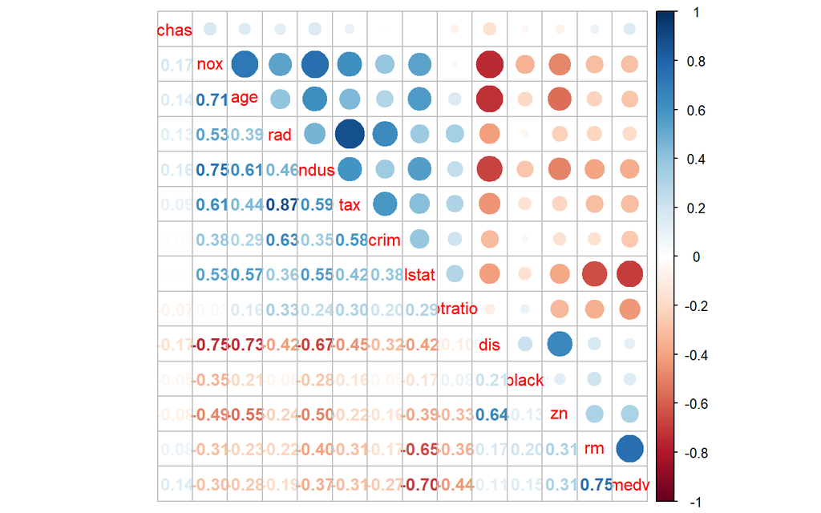

```r
#install.packages("corrplot")
library(corrplot)
matrix_correlation=round(cor(training_data),2)
corrplot.mixed(corr =matrix_correlation,order = 'AOE' )
```

14. What is the correlation between tax and rad?

```r
cor(training_data$tax,training_data$rad)
```

```
## [1] 0.8681268
```

15. Run the model again without `tax`. What happens to the $R^2$ ? and for the `F-statistic`?

```r
model3=lm(medv~.+ log(lstat) -lstat -tax,data=training_data)
summary(model3)
```

```
##
## Call:
## lm(formula = medv ~ . + log(lstat) - lstat - tax, data = training_data)
##
## Residuals:
##      Min       1Q   Median       3Q      Max
## -18.8470  -2.5354  -0.2791   1.9508  23.3798
##
## Coefficients:
##               Estimate Std. Error t value Pr(>|t|)
## (Intercept)  4.624e+01  5.944e+00   7.779 6.70e-14 ***
## crim        -1.844e-01  4.877e-02  -3.782 0.000180 ***
## zn           1.692e-02  1.261e-02   1.341 0.180600
## indus       -3.080e-02  5.686e-02  -0.542 0.588310
## chas         1.845e+00  8.096e-01   2.279 0.023184 *
## nox         -1.598e+01  4.123e+00  -3.876 0.000125 ***
## rm           3.431e+00  4.681e-01   7.329 1.36e-12 ***
## age          2.882e-02  1.334e-02   2.160 0.031412 *
## dis         -1.146e+00  1.939e-01  -5.909 7.54e-09 ***
## rad          2.063e-01  5.403e-02   3.817 0.000157 ***
## ptratio     -7.658e-01  1.279e-01  -5.989 4.82e-09 ***
## black        3.066e-04  5.940e-03   0.052 0.958855
## log(lstat)  -8.753e+00  6.558e-01 -13.347  < 2e-16 ***
## ---
## Signif. codes:  0 '***' 0.001 '**' 0.01 '*' 0.05 '.' 0.1 ' ' 1
##
## Residual standard error: 4.39 on 387 degrees of freedom
## Multiple R-squared:  0.7775, Adjusted R-squared:  0.7706
## F-statistic: 112.7 on 12 and 387 DF,  p-value: < 2.2e-16
```

```r
#R^2 a diminue legerement
#F-statistique 112.7 a  augmentee
```

```r
prediction1=predict(model3,testing_data)
MSE=mean((testing_data$medv-prediction1)^2)
MSE
```

```
## [1] 23.33963
```

`Anova`

Next we will apply an analysis of variances (`ANOVA`) in order to test if there is a significant difference of means between two groups `i` and `j` (Consider group `i` is the suburbs bounding the river and `j` the suburbs which not). The hypotheses are

$H0:μ_i=μ_j$

Where $μ_i$ is the mean of `medv` in group `i`.

17. In the Boston data set there is a categorical variable `chas` which corresponds to Charles River (= 1 if a suburb bounds the river; 0 otherwise). Use command `str()` to see how this variable is present in the dataset. How many of the suburbs in this data set bound the Charles river?

```r
str(Boston$chas)
```

```
##  int [1:506] 0 0 0 0 0 0 0 0 0 0 ...
```

```r
nrow(subset(Boston, chas==1))
```

```
## [1] 35
```

18. Create Boxplots of the median value of houses with respect to the variable `chas`. Do we observe some difference between the median value of houses with respect to the neighborhood to Charles River?

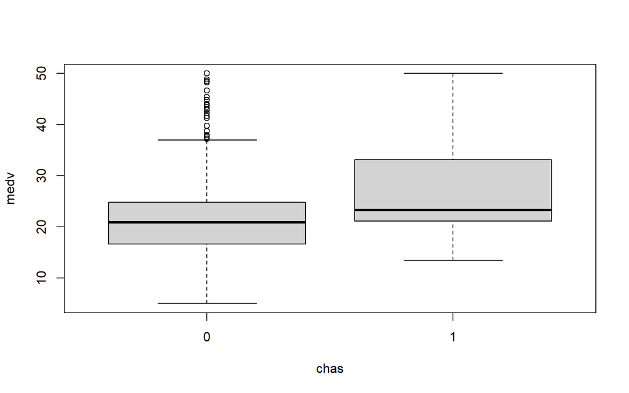

```r
boxplot(medv~chas, data=Boston)
```

```r
#there is a difference of median value
```

19. Calculate $μ_i$ and $μ_j$ (in one line using the function `aggregate()`).

```r
aggregate(medv ~ chas, data = training_data, FUN = mean)
```

```
##   chas     medv
## 1    0 23.94082
## 2    1 28.44000
```

20. Apply an `ANOVA` test of `medv` whith respect to `chas` (use the function `aov()`). Print the result and the summary of it. what do you conclude ?

```r
rep=aov(medv~chas, data=training_data)
rep
```

```
## Call:
##    aov(formula = medv ~ chas, data = training_data)
##
## Terms:
##                     chas Residuals
## Sum of Squares    646.50  32876.31
## Deg. of Freedom        1       398
##
## Residual standard error: 9.088662
## Estimated effects may be unbalanced
```

```r
summary(rep)
```

```
##              Df Sum Sq Mean Sq F value Pr(>F)
## chas          1    646   646.5   7.826 0.0054 **
## Residuals   398  32876    82.6
## ---
## Signif. codes:  0 '***' 0.001 '**' 0.01 '*' 0.05 '.' 0.1 ' ' 1
```

`Qualitative predictors`